# Assignment 1

Tanner Bivins, Emmett Saulnier, Brock Wilson

4/29/2021

For this problem you will estimate a regression discontinuity design to test whether having a BAC over the legal limits. You can compare this to the paper by yours truly about DUI punishments we read earlier.

### Part A

**Create a histogram of the running variable, BAC. Make sure you do it allowing for discrete bins. Is there evidence of clear sorting at the threshold?**

#### Solution

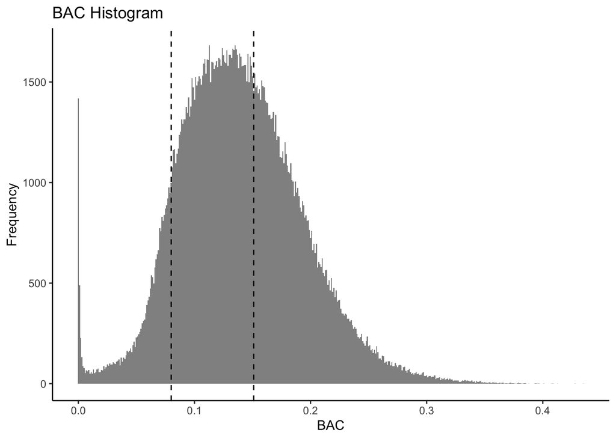

```r
# Loading Data
bac = data.table(read.csv(here("bac.csv")))

# Histogram of BAC
ggplot(data = bac, aes(x = bac)) +
  geom_histogram(binwidth = 0.001, alpha = 0.7) +
  geom_vline(xintercept = 0.08, linetype = "dashed") +
  geom_vline(xintercept = 0.151, linetype = "dashed") +
  labs(title ="BAC Histogram",
       x = "BAC",
       y = "Frequency") +
  theme_classic()
```

The histogram does not show evidence of sorting at either the 0.08 or 0.15 threshold, as the distribution is smooth on either side of both thresholds.

### Part B

**Get the R package rddensity. Perform a density test on the running variable. Is there evidence of sorting?**

#### Solution

```r
# Testing for sorting at both thresholds
rd_dens_08 = rddensity(X = bac$bac, c = 0.08, kernel = "uniform")
rd_dens_151 = rddensity(X = bac$bac, c = 0.151, kernel = "uniform")
```

The density test does not provide evidence of sorting. For the 0.08 threshold, the t-stat is 1.006 with corresponding p-value of 0.314. For the 0.151 threshold, the t-stat is -0.278 with corresponding p-value of 0.781. Thus, in both cases we fail to reject the null hypothesis that there is no sorting.

### Part C

**Next run a regression discontinuity model. To do so, create a dummy variable for a BAC over .08. Include that dummy variable, and the rescaled BAC (BAC-.08) as a control, and also include an interaction between that dummy variable and the running variable in model. First use age, gender, accident at the scene and race as outcomes. Do those factors shift at .08?**

#### Solution

```r
# Creating indicator variables for BAC over thresholds and rescaling
bac[,`:=`(
      drunk_08 = ifelse(bac > 0.08, 1, 0),
      drunk_151 = ifelse(bac > 0.151, 1, 0),
      rescaled_bac_08 = bac - 0.08,
      rescaled_bac_151 = bac - 0.151 )
]

# Binning
binwidth = 0.002
for (x in seq(-0.082, 0.36, binwidth)) {
  bac[rescaled_bac_08 >= x & rescaled_bac_08 < x + binwidth, bac_bins_08 := x]
}

bw = 0.05

bac08 = bac[bac<0.08+bw & bac > 0.08-bw,]

# Regressions to check if there are differences in observables near threshold
obs_models_08 = list (
  "Age" = lm(data = bac08, aged ~ drunk_08*rescaled_bac_08),
  "Male" = lm(data = bac08, male ~ drunk_08*rescaled_bac_08),
  "Accident" = lm(data = bac08, acc ~ drunk_08*rescaled_bac_08),
  "White" = lm(data = bac08, white ~ drunk_08*rescaled_bac_08)
)


# Reporting regression results
modelsummary(
  obs_models_08,
  stars = TRUE,
  coef_rename = c("drunk_08" = "DUI Threshold",
                  "rescaled_bac_08" = "BAC",
                  "drunk_08:rescaled_bac_08" = "DUI × BAC"),
  gof_omit = 'AIC|BIC|Log.Lik',
  #coef_omit = "Intercept",
  title = "Regression Discontinuity Estimates for the Impact of Exceeding DUI Threshold on Observable Characteristics"
)
```

Regression Discontinuity Estimates for the Impact of Exceeding DUI Threshold on Observable Characteristics

|  | Age | Male | Accident | White |
| --- | --- | --- | --- | --- |
| (Intercept) | 33.923*** | 0.785*** | 0.083*** | 0.848*** |
|  | (0.126) | (0.004) | (0.003) | (0.004) |
| DUI Threshold | -0.165 | 0.006 | -0.002 | 0.004 |
|  | (0.157) | (0.006) | (0.004) | (0.005) |
| BAC | -66.518*** | -0.175 | -1.044*** | 0.055 |
|  | (6.622) | (0.232) | (0.173) | (0.203) |
| DUI × BAC | 73.753*** | 0.295 | 1.901*** | 0.049 |
|  | (7.324) | (0.257) | (0.191) | (0.224) |
| Num.Obs. | 92158 | 92158 | 92158 | 92158 |
| R2 | 0.002 | 0.000 | 0.002 | 0.000 |
| R2 Adj. | 0.002 | 0.000 | 0.002 | 0.000 |
| F | 71.486 | 1.859 | 50.239 | 2.721 |

* p < 0.1, ** p < 0.05, *** p < 0.01

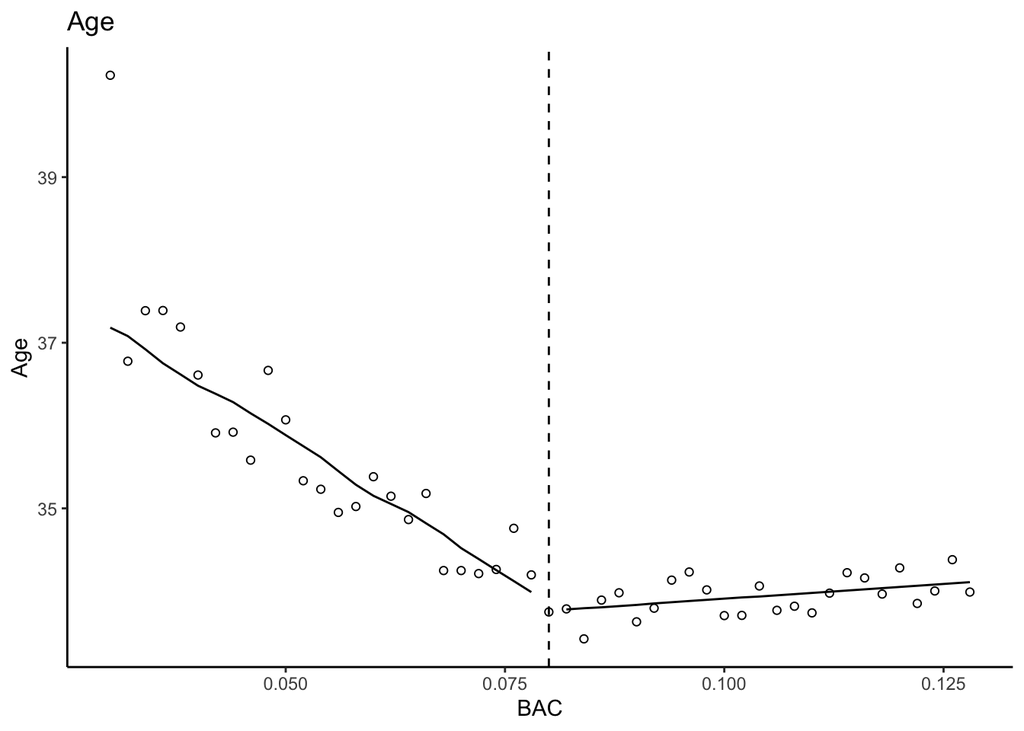

```r
# Adding the fitted values for age, gender, and accident
bac08$fitaged = predict(obs_models_08[["Age"]])
bac08$fitmale = predict(obs_models_08[["Male"]])
bac08$fitacc = predict(obs_models_08[["Accident"]])
bac08$fitwhite = predict(obs_models_08[["White"]])


#bac$bac_bins_08 = cut(
#  x = bac$rescaled_bac_08,
#  breaks = seq(-0.082, 0.36, 0.002),
#  ordered_result = TRUE
#)


# Calculating averages for observables by bin
bac_average_08 = bac08[,
    lapply(.SD, mean, na.rm =TRUE),
    .SDcols = c("aged","male","acc","white", "fitaged", "fitmale", "fitacc","fitwhite"),
    by = bac_bins_08]

bac_average_08[, cont_bin := bac_bins_08]


# Function that will generate RD plots
# Note that you must use "quote(dep_var)" in arguments for it to work
rd_plot = function(data, dep_var, fit_var, threshold) {
  p = ggplot(data = data, aes(x = cont_bin + threshold, y = eval(dep_var))) +
        geom_point(shape = 1) +
        geom_line(data = data[cont_bin < 0,], aes(y = eval(fit_var))) +
        geom_line(data = data[cont_bin > 0,], aes(y = eval(fit_var))) +
        xlab("BAC")+
        theme_classic() +
        geom_vline(xintercept = threshold, linetype = "dashed")
  return(p)
}

# Age
rd_plot(bac_average_08, quote(aged), quote(fitaged), 0.08)+
        labs(title = "Age", y = "Age")
```

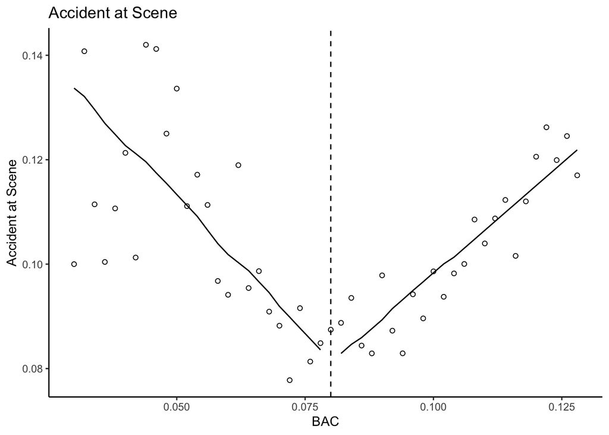

```r
# Accident
rd_plot(bac_average_08, quote(acc), quote(fitacc), 0.08)+
        labs(title = "Accident at Scene", y = "Accident at Scene")
```

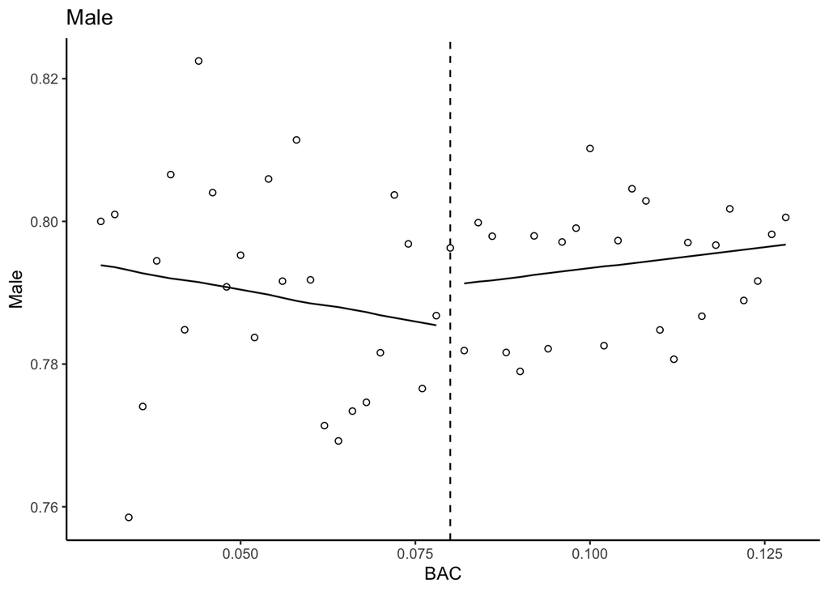

```r
# Male
rd_plot(bac_average_08, quote(male), quote(fitmale), 0.08)+
        labs(title = "Male", y = "Male")
```

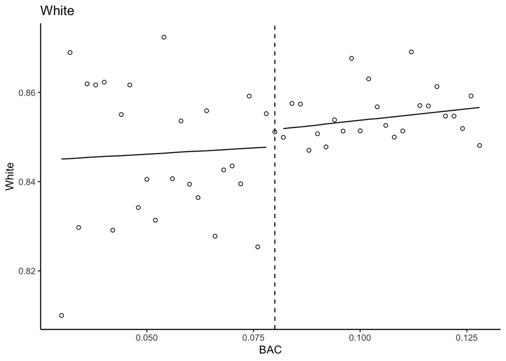

```r
# White
rd_plot(bac_average_08, quote(white), quote(fitwhite), 0.08)+
        labs(title = "White", y = "White")
```

There is not evidence of sorting on the observable characteristics seen here, age, gender, accident at scene, or race, at the DUI threshold of 0.08.

### Part D

**Now run a regression of recidivism on the same regression discontinuity design. What is your estimated effect using a bandwidth of .05, and a rectangular kernel (no weighting). Create a visualization of this by graphing the mean recidivism rate against the running variable. Show this for the whole BAC distribution, and the range from .03 to .13. Please include a fitted line.**

#### Solution

```r
# Censoring data using bandwidth of 0.05
bac_censored_08 = bac[rescaled_bac_08 <= 0.05 & rescaled_bac_08 >= -0.05,]

# Running RD models with and without controls
rd_models_08 = list(
  "No Controls" = lm(data = bac_censored_08,
           recidivism ~ drunk_08*rescaled_bac_08),
  "With Controls" = lm(data = bac_censored_08,
           recidivism ~ drunk_08*rescaled_bac_08 + aged + male + acc)
)

# Reporting regression results
modelsummary(
  rd_models_08,
  stars = TRUE,
  coef_rename = c("drunk_08"="DUI Threshold",
                  "rescaled_bac_08"="BAC",
                  "drunk_08:rescaled_bac_08" = "DUI × BAC"),
  gof_omit = 'AIC|BIC|Log.Lik',
  #coef_omit = "Intercept",
  title = "Regression Discontinuity Estimates for the Impact of Exceeding DUI Threshold on Recidivism"
)
```

Regression Discontinuity Estimates for the Impact of Exceeding DUI Threshold on Recidivism

|  | No Controls | With Controls |
| --- | --- | --- |
| (Intercept) | 0.112*** | 0.115*** |
|  | (0.003) | (0.005) |
| DUI Threshold | -0.019*** | -0.019*** |
|  | (0.004) | (0.004) |
| BAC | -0.261 | -0.308* |
|  | (0.177) | (0.177) |
| DUI × BAC | 0.684*** | 0.731*** |
|  | (0.195) | (0.195) |
| aged |  | -0.001*** |
|  |  | (0.000) |
| male |  | 0.033*** |
|  |  | (0.002) |
| acc |  | 0.003 |
|  |  | (0.003) |
| Num.Obs. | 93792 | 93792 |
| R2 | 0.001 | 0.003 |
| R2 Adj. | 0.001 | 0.003 |
| F | 16.739 | 52.018 |

* p < 0.1, ** p < 0.05, *** p < 0.01

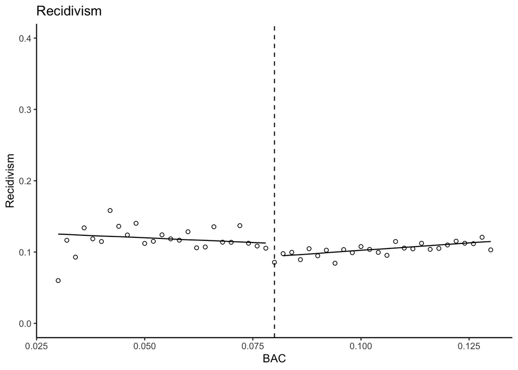

```r
# Getting fitted values
bac_censored_08$fitrecid = predict(rd_models_08[["No Controls"]])

#### Graphing mean recidivism
bac_average = bac[,
    lapply(.SD, mean, na.rm =TRUE),
    .SDcols = c("recidivism"),
    by = bac_bins_08]

# Fitted data
bac_average2 = bac_censored_08[,
    lapply(.SD, mean, na.rm =TRUE),
    .SDcols = c("fitrecid"),
    by = bac_bins_08]

# Merging with rest of the data
bac_avg = merge(bac_average_08,bac_average, by="bac_bins_08") %>%
  merge(bac_average2, by="bac_bins_08", all.x = TRUE)


# Plotting the RD
rd_plot(bac_avg, quote(recidivism), quote(fitrecid), 0.08) +
  xlim(0.03,0.13) +
  ylim(0,0.4) +
  labs(title = "Recidivism", y = "Recidivism")
```

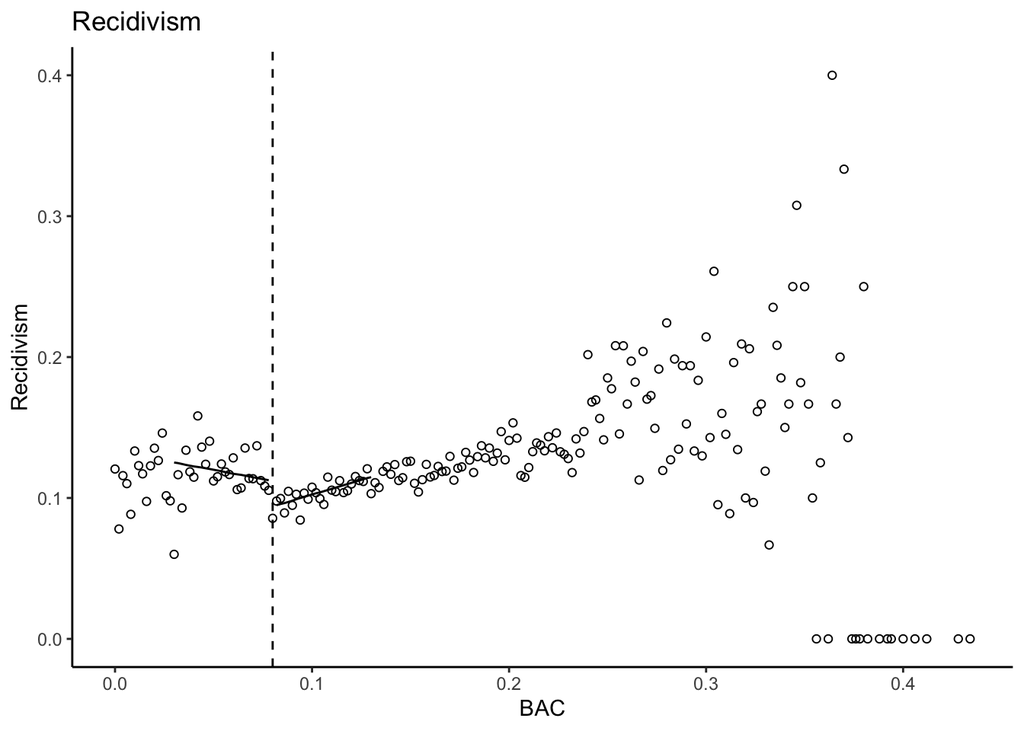

```r
rd_plot(bac_avg, quote(recidivism), quote(fitrecid), 0.08) +
  ylim(0,0.4) +
  labs(title = "Recidivism", y = "Recidivism")
```

### Part E

**Do the same thing as part c and d but for the aggravated threshold of .151.**

#### Solution

```r
bac[,`:=`(
      drunk_08 = ifelse(bac > 0.08, 1, 0),
      drunk_151 = ifelse(bac > 0.151, 1, 0),
      rescaled_bac_08 = bac - 0.08,
      rescaled_bac_151 = bac - 0.151 )
]

# Binning
binwidth = 0.002
for (x in seq(-0.152, 0.29, binwidth)) {
  bac[rescaled_bac_151 >= x & rescaled_bac_151 < x + binwidth, bac_bins_151 := x]
}

bw = 0.05
bac151 = bac[bac>0.151-bw & bac<0.151+bw,]

obs_models_151 = list (
  "Age" = lm(data = bac151, aged ~ drunk_151*rescaled_bac_151),
  "Male" = lm(data = bac151, male ~ drunk_151*rescaled_bac_151),
  "Accident" = lm(data = bac151, acc ~ drunk_151*rescaled_bac_151),
  "White" = lm(data = bac151, white ~ drunk_151*rescaled_bac_151)
)


# Reporting regression results
modelsummary(
  obs_models_151,
  stars = TRUE,
  coef_rename = c("drunk_151"="Aggr DUI Threshold",
                  "rescaled_bac_151"="BAC",
                  "drunk_151:rescaled_bac_151" = "Aggr DUI × BAC"),
  gof_omit = 'AIC|BIC|Log.Lik',
  #coef_omit = "Intercept",
  title = "Regression Discontinuity Estimates for the Impact of Exceeding Aggrevated DUI Threshold on Observable Characteristics"
)
```

Regression Discontinuity Estimates for the Impact of Exceeding Aggrevated DUI Threshold on Observable Characteristics

|  | Age | Male | Accident | White |
| --- | --- | --- | --- | --- |
| (Intercept) | 34.525*** | 0.791*** | 0.145*** | 0.865*** |
|  | (0.079) | (0.003) | (0.002) | (0.002) |
| Aggr DUI Threshold | 0.067 | -0.005 | 0.007* | 0.005 |
|  | (0.120) | (0.004) | (0.004) | (0.004) |
| BAC | 15.354*** | -0.124 | 0.994*** | 0.256*** |
|  | (2.748) | (0.098) | (0.085) | (0.083) |
| Aggr DUI × BAC | 10.652** | 0.220 | 0.246* | -0.233* |
|  | (4.423) | (0.158) | (0.136) | (0.133) |
| Num.Obs. | 137621 | 137621 | 137621 | 137621 |
| R2 | 0.003 | 0.000 | 0.009 | 0.000 |
| R2 Adj. | 0.003 | 0.000 | 0.009 | 0.000 |
| F | 119.213 | 3.279 | 405.770 | 16.590 |

* p < 0.1, ** p < 0.05, *** p < 0.01

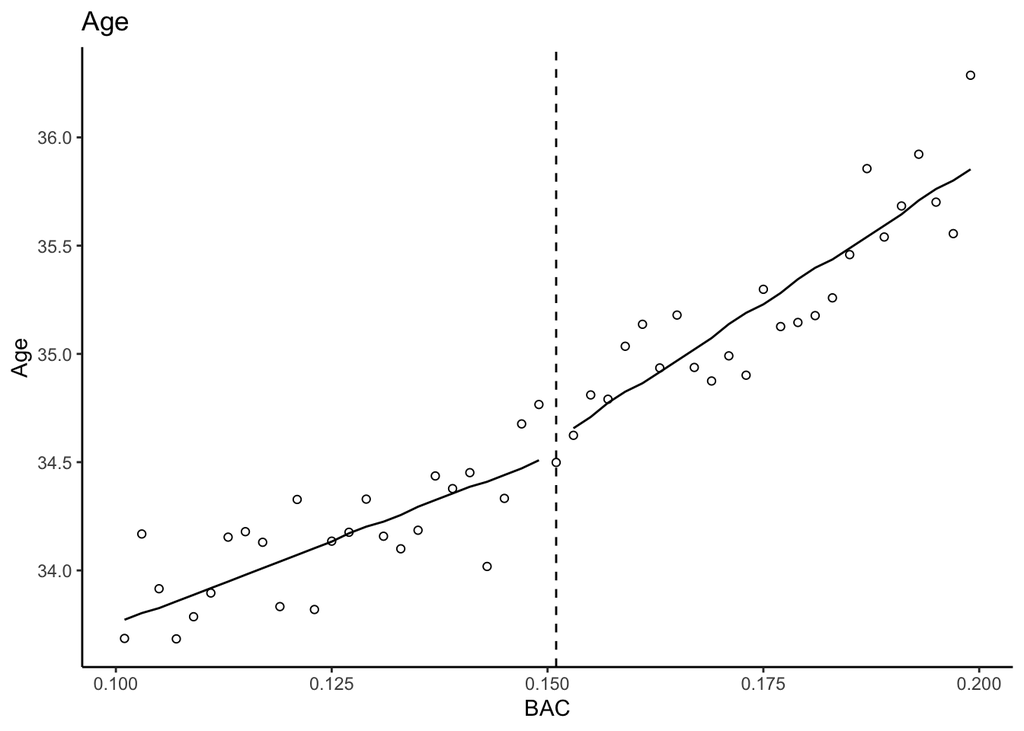

```r
# Adding the fitted values for age, gender, and accident
bac151$fitaged_151 = predict(obs_models_151[["Age"]])
bac151$fitmale_151 = predict(obs_models_151[["Male"]])
bac151$fitacc_151 = predict(obs_models_151[["Accident"]])
bac151$fitwhite_151 = predict(obs_models_151[["White"]])


# Calculating averages for observables by bin
bac_average_151 = bac151[,
    lapply(.SD, mean, na.rm =TRUE),
    .SDcols = c("aged","male","acc","white", "fitaged_151", "fitmale_151", "fitacc_151","fitwhite_151"),
    by = bac_bins_151]

bac_average_151[, cont_bin := bac_bins_151]


# Function that will generate RD plots
# Note that you must use "quote(dep_var)" in arguments for it to work
rd_plot = function(data, dep_var, fit_var, threshold) {
  p = ggplot(data = data, aes(x = cont_bin + threshold, y = eval(dep_var))) +
        geom_point(shape = 1) +
        geom_line(data = data[cont_bin < 0,], aes(y = eval(fit_var))) +
        geom_line(data = data[cont_bin > 0,], aes(y = eval(fit_var))) +
        xlab("BAC")+
        theme_classic() +
        geom_vline(xintercept = threshold, linetype = "dashed")
  return(p)
}

# Age
rd_plot(bac_average_151, quote(aged), quote(fitaged_151), 0.151)+
        labs(title = "Age", y = "Age")
```

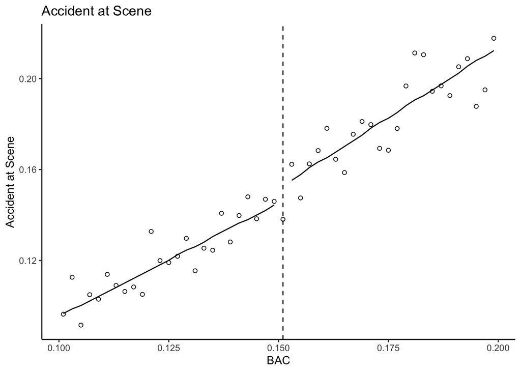

```r
# Accident
rd_plot(bac_average_151, quote(acc), quote(fitacc_151), 0.151)+
        labs(title = "Accident at Scene", y = "Accident at Scene")
```

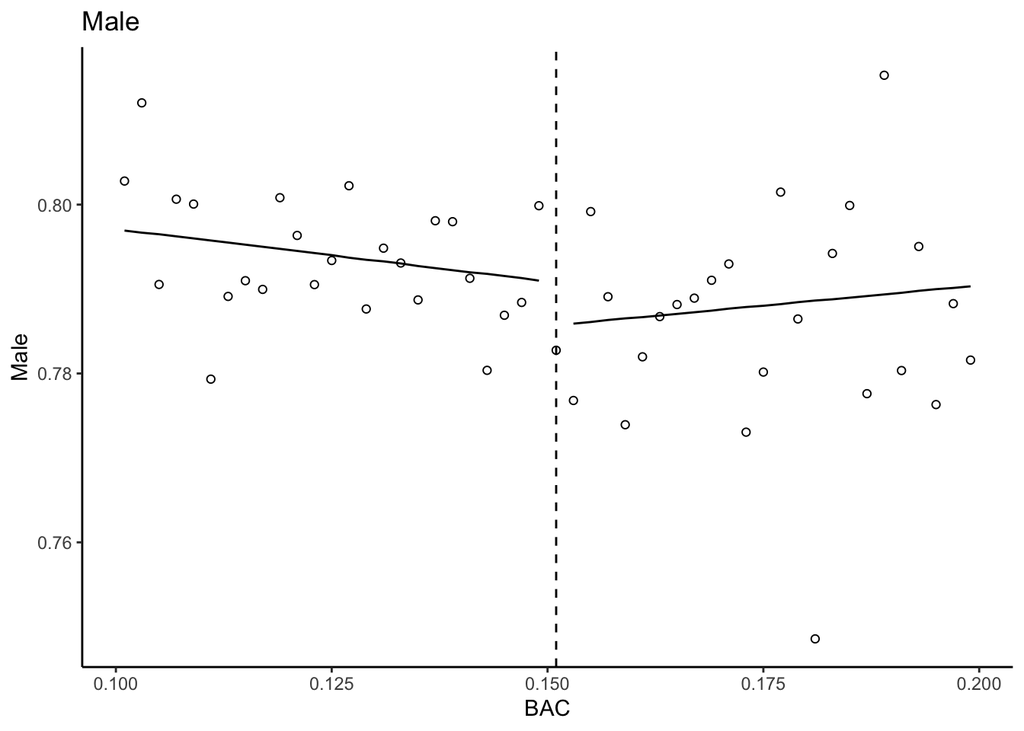

```r
# Male
rd_plot(bac_average_151, quote(male), quote(fitmale_151), 0.151)+
        labs(title = "Male", y = "Male")
```

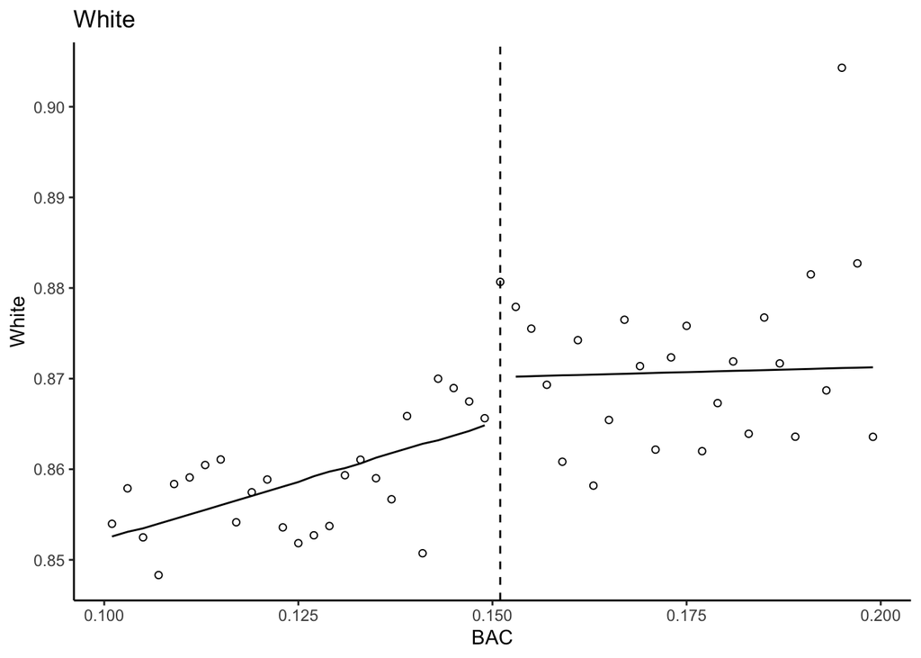

```r
# White
rd_plot(bac_average_151, quote(white), quote(fitwhite_151), 0.151)+
        labs(title = "White", y = "White")
```

```r
###############################################
########### Effect on Recidivism ##############
###############################################

# Censoring data using bandwidth of 0.05
bac_censored_151 = bac[rescaled_bac_151 <= 0.05 & rescaled_bac_151 >= -0.05,]

# Running RD models with and without controls
rd_models_151 = list(
  "No Controls" = lm(data = bac_censored_151,
           recidivism ~ drunk_151*rescaled_bac_151),
  "With Controls" = lm(data = bac_censored_151,
           recidivism ~ drunk_151*rescaled_bac_151 + aged + male + acc)
)

# Reporting regression results
modelsummary(
  rd_models_151,
  stars = TRUE,
  coef_rename = c("drunk_151"="Aggr DUI Threshold",
                  "rescaled_bac_151"="BAC",
                  "drunk_151:rescaled_bac_151" = "Aggr DUI × BAC"),
  gof_omit = 'AIC|BIC|Log.Lik',
  #coef_omit = "Intercept",
  title = "Regression Discontinuity Estimates for the Impact of Exceeding Aggrevated DUI Threshold on Recidivism"
)
```

Regression Discontinuity Estimates for the Impact of Exceeding Aggrevated DUI Threshold on Recidivism

|  | No Controls | With Controls |
| --- | --- | --- |
| (Intercept) | 0.122*** | 0.125*** |
|  | (0.002) | (0.004) |
| Aggr DUI Threshold | -0.011*** | -0.011*** |
|  | (0.003) | (0.003) |
| BAC | 0.414*** | 0.437*** |
|  | (0.077) | (0.077) |
| Aggr DUI × BAC | 0.091 | 0.095 |
|  | (0.124) | (0.124) |
| aged |  | -0.001*** |
|  |  | (0.000) |
| male |  | 0.029*** |
|  |  | (0.002) |
| acc |  | -0.009*** |
|  |  | (0.002) |
| Num.Obs. | 137621 | 137621 |
| R2 | 0.001 | 0.003 |
| R2 Adj. | 0.001 | 0.003 |
| F | 30.196 | 63.621 |

* p < 0.1, ** p < 0.05, *** p < 0.01

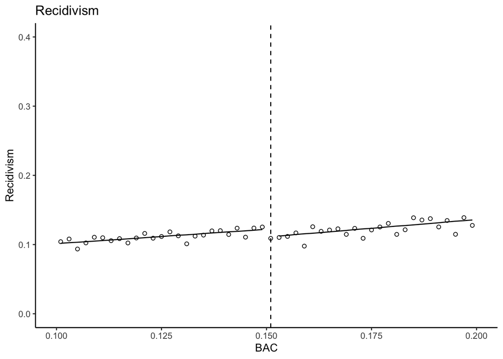

```r
# Getting fitted values
bac_censored_151$fitrecid_151 = predict(rd_models_151[["No Controls"]])

#### Graphing mean recidivism
bac_average = bac[,
    lapply(.SD, mean, na.rm =TRUE),
    .SDcols = c("recidivism"),
    by = bac_bins_151]

# Fitted data
bac_average2 = bac_censored_151[,
    lapply(.SD, mean, na.rm =TRUE),
    .SDcols = c("fitrecid_151"),
    by = bac_bins_151]

# Merging with rest of the data
bac_avg = merge(bac_average_151,bac_average, by="bac_bins_151") %>%
  merge(bac_average2, by="bac_bins_151", all.x = TRUE)


# Plotting the RD
rd_plot(bac_avg, quote(recidivism), quote(fitrecid_151), 0.151) +
  xlim(0.10,0.20) +
  ylim(0,0.4) +
  labs(title = "Recidivism", y = "Recidivism")
```

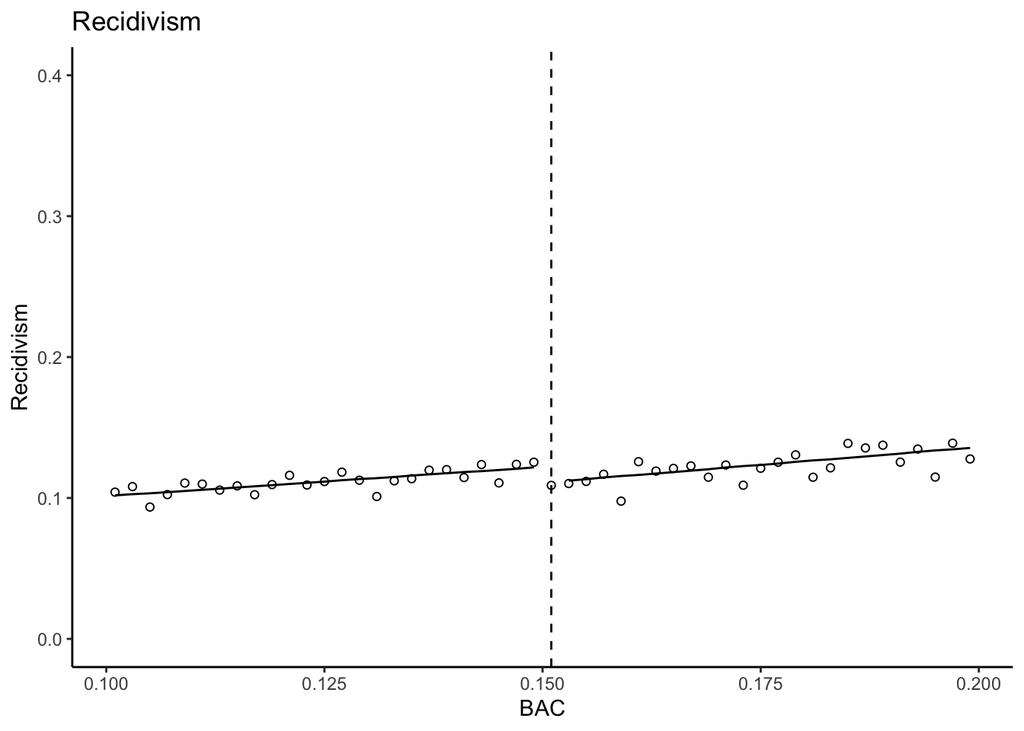

```r
rd_plot(bac_avg, quote(recidivism), quote(fitrecid_151), 0.151) +
  ylim(0,0.4) +
  labs(title = "Recidivism", y = "Recidivism")
```

### Part F

**Now run this model for every possible bandwidth between .01 and .07. Store both the point estimates and lower and upper confidence intervals. Create a scatter plot of the confidence interval and the point estimates. Are the estimates robust? Create a visualization of this.**

#### Solution

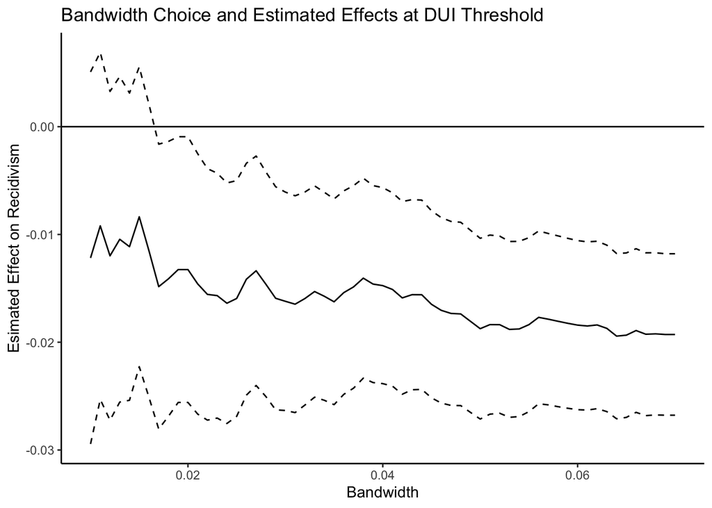

```r
# Writing a function that estimates coefficients for given bandwidth and threshold
rd_bw = function(bw, threshold){

  # Rescaling and creating indicator based on threshold
  bac$rescaled_bac = bac$bac - threshold
  bac$drunk = ifelse(bac$rescaled_bac > 0, 1, 0)

  # Censoring data to within bandwidth
  bac2 = bac[rescaled_bac <= bw & rescaled_bac >= -bw,]

  # Running regression model
  mod_recid = lm(data = bac2, recidivism ~ drunk*rescaled_bac)

  # Collecting results
  estimate = broom::tidy(mod_recid)[2,2]
  t_stat = broom::tidy(mod_recid)[2,4]
  lower_bound = broom::tidy(mod_recid)[2,2] - 2* broom::tidy(mod_recid)[2,3]
  upper_bound = broom::tidy(mod_recid)[2,2] + 2* broom::tidy(mod_recid)[2,3]

  # Returning the results
  output = data.frame(threshold, bw, estimate, lower_bound, upper_bound, t_stat)
  return(output)

}

# Threshold = 0.08
bandwidth_08 = map_dfr(.x = seq(0.01, 0.07, 0.001), .f = rd_bw, threshold = 0.08)
colnames(bandwidth_08) = c("threshold", "bw", "estimate", "lower_bound", "upper_bound")

# Plotting Estimates
ggplot(data = bandwidth_08, aes(x = bw, y = estimate)) +
  geom_line() +
  geom_line(aes(y = upper_bound), linetype = "dashed") +
  geom_line(aes(y = lower_bound), linetype = "dashed") +
  geom_hline(yintercept = 0)+
  theme_classic() +
  labs(title = "Bandwidth Choice and Estimated Effects at DUI Threshold",
       x = "Bandwidth",
       y = "Esimated Effect on Recidivism")
```

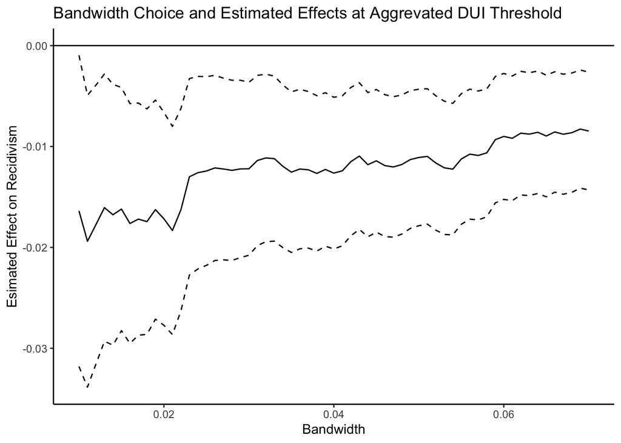

```r
# Threshold = 0.151
bandwidth_151 = map_dfr(.x = seq(0.01, 0.07, 0.001), .f = rd_bw, threshold = 0.151)
colnames(bandwidth_151) = c("threshold", "bw", "estimate", "lower_bound", "upper_bound")


# Plotting Estimates
ggplot(data = bandwidth_151, aes(x = bw, y = estimate)) +
  geom_line() +
  geom_line(aes(y = upper_bound), linetype = "dashed") +
  geom_line(aes(y = lower_bound), linetype = "dashed") +
  geom_hline(yintercept = 0)+
  theme_classic() +
  labs(title = "Bandwidth Choice and Estimated Effects at Aggrevated DUI Threshold",
       x = "Bandwidth",
       y = "Esimated Effect on Recidivism")
```

### Part G

**Finally, I want you to reestimate your models using instead of the .08 threshold, every other BAC as the threshold, keeping a bandwidth of .03, between .03 and .12 (i.e. .03, .031, .032, etc). Create a scatter plot of both the point estimates (yaxis) against the potential RD thresholds (x axis). Now create a scatter plot of your test statistic on the null hypothesis of your point estimates (z-stat/t-stat) with the test statistic on the y axis, and the threshold on the x axis. What is the rank of (1 being the largest) of your point estimate estimated at .08? How many estimates did you do? The rank divided by the number of tests is called an empirical p-value based on a form of permutation inference.**

#### Solution:

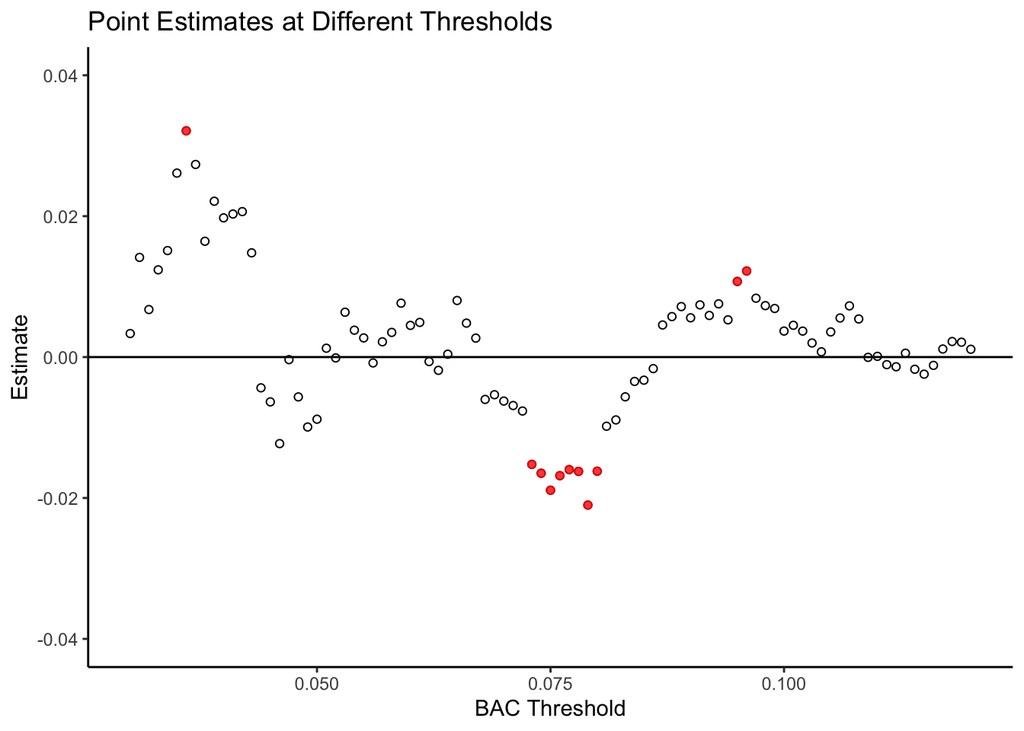

```r
# reordering argument order so that we can still use map function
rd_bw2 = function(threshold, bw){
  return(rd_bw(bw, threshold))
}

# Testing at all thresholds between 0.03 and 0.12
output_g = map_dfr(.x = seq(0.03, 0.12, 0.001), .f = rd_bw2, bw = 0.03)
colnames(output_g) = c("threshold", "bw", "estimate", "lower_bound", "upper_bound", "t_stat")
output_g = data.table(output_g)

# Plot of point estimates
ggplot(data = output_g, aes(x = threshold, y = estimate)) +
  geom_point(shape = 1) +
  geom_point(data = output_g[t_stat > 1.96 | t_stat < -1.96], aes(x = threshold,y = estimate), color = "red", alpha = 0.8)+
  #geom_hline(yintercept = mean(output_g[, estimate]), linetype = "dashed") +
  geom_hline(yintercept = 0) +
  ylim(-0.04,0.04)+
  theme_classic() +
  labs(title = "Point Estimates at Different Thresholds",
       x = "BAC Threshold",
       y = "Estimate")
```

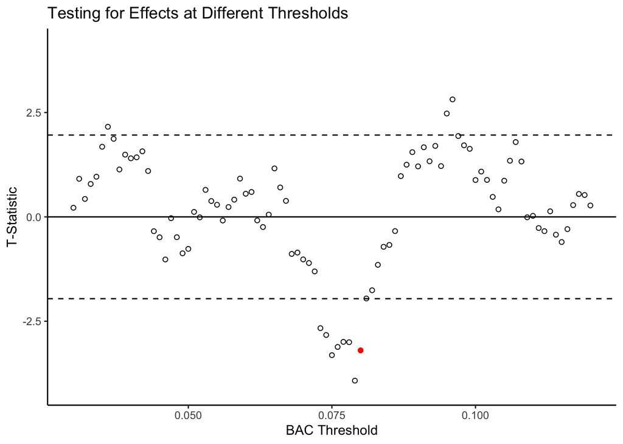

```r
# Plot of T Stats
ggplot(data = output_g, aes(x = threshold, y = t_stat)) +
  geom_point(shape = 1) +
  geom_point(data = output_g[threshold==0.08], aes(x=threshold,y=t_stat), color = "red")+
  geom_hline(yintercept = 0) +
  geom_hline(yintercept = -1.96, linetype = "dashed") +
  geom_hline(yintercept = 1.96, linetype = "dashed") +
  ylim(-4.1,4.1)+
  theme_classic() +
  labs(title = "Testing for Effects at Different Thresholds",
       x = "BAC Threshold",
       y = "T-Statistic")
```

```r
# Number of Permutations
den = nrow(output_g)

# Rank of 0.08 Threshold
output_g$rank_onesided = rank(output_g$t_stat)
output_g$rank_twosided = rank(-abs(output_g$t_stat))

num_onesided = output_g[threshold == 0.08, "rank_onesided"]
num_twosided = output_g[threshold == 0.08, "rank_twosided"]

# Permutation Test
p_value_onesided = num_onesided/den
p_value_twosided = num_twosided/den
```

If the alternative hypothesis in question is that recidivism decreases at the threshold, then we can conduct a one sided test by ranking the t-stats created using different thresholds, with the smallest (most negative) being ranked the highest. In this case, the rank of the point estimate for a threshold of 0.08 is 3, where we have calculated 91 estimates. This gives a p-value for the one-sided permutation test of 0.033.

If the alternative hypothesis in question is that there is a change in recidivism at the threshold, then we can conduct a two sided test by ranking the absolute value of the t-stats created using different thresholds, with the largest being ranked the highest. In this case, the rank of the point estimate for a threshold of 0.08 is also 3. This gives a p-value for the two-sided permutation test of 0.033.